# Dia da Mulher na Ciência

11 de Fevereiro

Neste ano, o grupo GENt comemora novamente o Dia da Mulher na Ciência no Departamento de Genética da ESALQ. Dessa vez, buscamos entender um pouco mais sobre como as pessoas de dentro do Departamento pensam sobre o tema através de um [formulário](https://forms.gle/poyF5XtjpB2dgi5W6) com algumas perguntas sobre o tema. Pedimos também que os participantes elaborassem uma frase para a data. A melhor frase foi premiada com uma camiseta do site.

Aqui discutiremos um pouco mais sobre as perguntas feitas no formulário.

- Qual o primeiro nome de cientista que lhe vem a cabeça? Respostas:

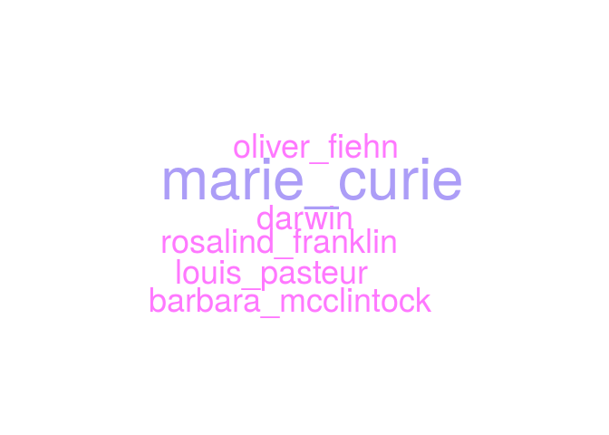

- Pense em 5 cientistas que você admira. Entre eles(as) quantos são brancos(as)? Quantos são homens? Quantos são mulheres? Respostas:

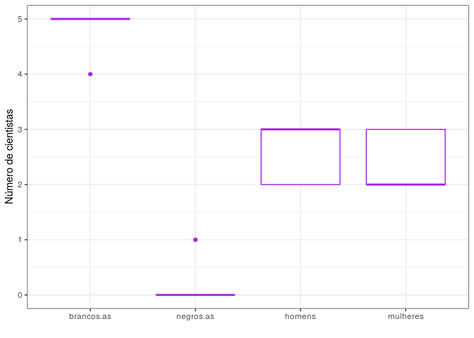

- Durante a sua formação acadêmica, qual a proporção de professores homens e mulheres que você teve na graduação e na pós-graduação? Respostas:

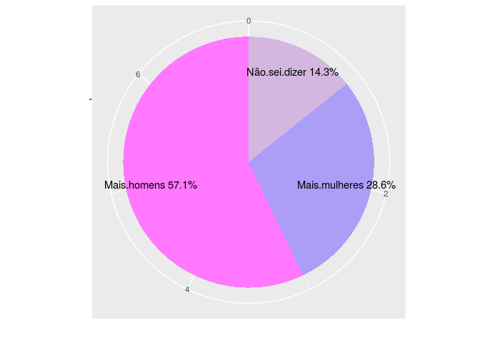

- Em qual área você imagina que a maior parte das mulheres com doutorado atuam? Respostas:

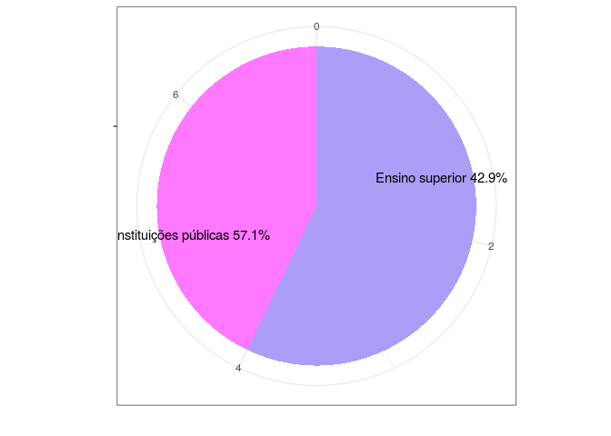

Ainda que a maior parte das mulheres com doutorado se dediquem a docência no ensino superior, em universidades renomadas, em cursos de ciência e tecnologia, a maioria dos professores ainda são homens. Em 2017, em toda a USP, dos quase 5844 professores, 37,81% são mulheres. [Fonte](https://jornal.usp.br/universidade/mulheres-fazem-ciencia-mas-ainda-estao-longe-do-topo/).

- Quantos pesquisadores no mundo são mulheres? Respostas:

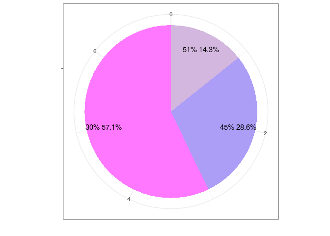

30% são mulheres e apenas 35% dessas mulheres pesquisam na área de ciência e tecnologia. [Fonte](https://www.unwomen.org/en/news/in-focus/international-day-of-women-and-girls-in-science).

- Entre as pessoas laureadas com prêmio Nobel, entre 1901 e 2019, quantas são mulheres? Respostas:

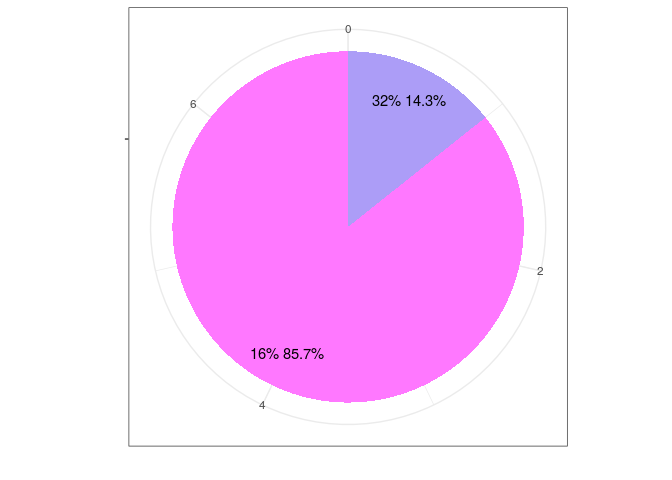

Dos 923 cientistas laureados com o prêmio , 54 foram mulheres, ou seja, 5.8% (nenhuma das opções dadas). Sendo que Marie Curie foi laureada duas vezes com o prêmio. [Fonte](https://www.nobelprize.org/prizes/facts/nobel-prize-facts/).

Vale também relembrar a foto que tiramos no ano passado! Acesse [aqui](https://www.esalq.usp.br/banco-de-noticias/esalqueanas-celebram-dia-internacional-das-mulheres-na-ci%C3%AAncia) a reportagem.

Também destacamos esta [reportagem](https://jornal.usp.br/universidade/mulheres-fazem-ciencia-mas-ainda-estao-longe-do-topo/)! Com a participação de uma de nossas queridas docentes: Maria Carolina Quecine Verdi.